# workshop.R

papenfuss

2020-05-01

# Cancer Genomics workshop

Author: Tony Papenfuss Date: Friday 1st May 2020

The code for this workshop is available here: http://bioinf.wehi.edu.au/~papenfuss/cancer_genomics_workshop/workshop.R

The html version of this document is available here: http://bioinf.wehi.edu.au/~papenfuss/cancer_genomics_workshop/workshop.html

In this practical class, we are going to perform copy number analysis on deep whole genome sequencing from a patient with well-differentiated liposarcoma from this paper:

Garsed/Marshall/Corbin et al, The Architecture and Evolution of Cancer Neochromosomes, Cancer Cell 26:5, P653-667, 2014 https://www.cell.com/cancer-cell/fulltext/S1535-6108(14)00373-0

The data is tumour only sequencing, so we will use a simple approach to the copy number calling using the R/Bioconductor package QDNA-seq,

https://www.bioconductor.org/packages/release/bioc/html/QDNAseq.html,

and explore the data in R and IGV. The raw data is publically available here:

https://www.ebi.ac.uk/ena/browser/view/PRJEB4696

First we install some dependencies.

```r
# Download and install R packages
#install.packages("tidyverse")


# Download Bioconductor packages

# Install scripts for older versions of Bioconductor
# source("https://bioconductor.org/biocLite.R")
# biocLite()
# biocLite("QDNAseq")

# For Bioconductor 3.10
if (!requireNamespace("BiocManager", quietly = TRUE))
  install.packages("BiocManager")
BiocManager::install(version = "3.10") # The current version (1/5/2020) is 3.11, but requires R 4.0.
BiocManager::install(c("QDNAseq"))
# Load R libraries
library(QDNAseq)
library(tidyverse)
```

By editing and uncommenting the following line you can change to whatever working directory you like.

```r
setwd("~/Desktop/cancer_genomics_workshop")
```

I have already aligned the reads to the hg19 reference genome and summarised the reads into counts.

QDNA-seq uses sets of pre-defined bins of various sizes with precalculated GC content and mappability. These were selected using the following commands.

```r
#  bins <- getBinAnnotations(binSize = 30, type = "SR50")
#  saveRDS(bins, file = "bins30K.dat")
```

binSize = 30 means that 30kb bins are used. type = “SR50” means that mappability is defined for 50nt single end reads. This is not quite right, as the data was 100nt paired end. Generating this data for 100nt long reads is very slow, but would improve the analysis a bit.

First we load the saved version of this. If you have downloaded all the data or created your own bin30K.dat file, you can load the bin data from a local file:

```r
# bins.filename = "file://bins30K.dat"

bins.filename = "http://bioinf.wehi.edu.au/~papenfuss/cancer_genomics_workshop/bins30K.dat"
bins = readRDS(gzcon(url(bins.filename)))
```

Binning reads into these bins is also pretty slow, so I have already done this. It was done using the following commands.

```r
#  filename = "/Users/papenfuss/projects/liposarcoma/data/ST059/ST059_NoIndex_bt2.bam"
#  readCounts = binReadCounts(bins, bamfiles = filename)
#  saveRDS(readCounts, file = "scratch/ST059_counts_30kb_bins.dat")
#
```

We just load it from a binary dat file.

```r
counts.filename = "http://bioinf.wehi.edu.au/~papenfuss/cancer_genomics_workshop/ST059_counts_30kb_bins.dat"
# counts.filename = "file://ST059_counts_30kb_bins.dat"
readCounts = readRDS(gzcon(url(counts.filename)))
```

To see what these look like, we can use the R command head

```r
head(bins)
```

```
## QDNAseq bin annotations for Hsapiens, build hg19.
## Created by Ilari Scheinin with QDNAseq 0.7.5, 2014-02-07 01:33:28.
## An object of class 'AnnotatedDataFrame'
##   rowNames: 1:1-30000 1:30001-60000 ... 1:150001-180000 (6 total)
##   varLabels: chromosome start ... use (9 total)
##   varMetadata: labelDescription
```

```r
head(readCounts)
```

```
## QDNAseqReadCounts (storageMode: lockedEnvironment)
## assayData: 1 features, 1 samples
##   element names: counts
## protocolData: none
## phenoData
##   sampleNames: ST059_NoIndex_bt2
##   varLabels: name total.reads used.reads expected.variance
##   varMetadata: labelDescription
## featureData
##   featureNames: 1:1-30000
##   fvarLabels: chromosome start ... use (9 total)
##   fvarMetadata: labelDescription
## experimentData: use 'experimentData(object)'
## Annotation:
```

These are R objects. Data sits in slots (featureData, assayData, etc) and can be accessed using the @ operator and then the $ operator.

```r
head(readCounts@assayData$counts)
```

```
##                 ST059_NoIndex_bt2
## 1:1-30000                      13
## 1:30001-60000                   7
## 1:60001-90000                   5
## 1:90001-120000                  1
## 1:120001-150000                 4
## 1:150001-180000                 6
```

Here’s another amazing copy number profile if you want to look.

```r
#  readCounts <- binReadCounts(bins, bamfiles = filename.all))
#  saveRDS(readCounts, file = "scratch/T1000_counts_30kb_bins.dat")
#
# readCounts = readRDS("scratch/T1000_counts_30kb_bins.dat")
```

Let’s have a look at the GC bias in the count data.

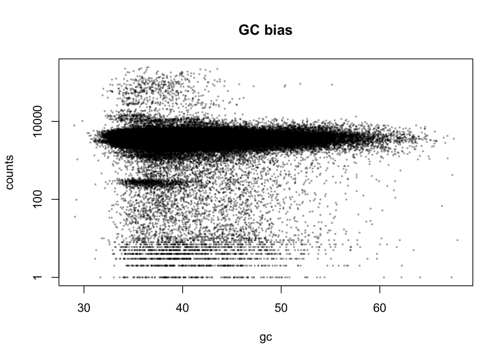

```r
GC.data = data.frame(
  gc = readCounts@featureData@data$gc,
  counts = readCounts@assayData$counts[, 1]
)
plot(counts~gc, GC.data, pch=20, cex=0.4, col="#00000044", log="y", main="GC bias")
```

This looks quite flat (excellent), but does show some banding which corresponds to different copy number states.

Now lets have a look at the count data across the genome using the default QDNA-seq plots.

```r
plot(readCounts, logTransform=FALSE, main="Read counts")
```

```
## Plotting sample Read counts (395,403,678 reads) (1 of 1) ...
```

```r
highlightFilters(
  readCounts,
  logTransform = FALSE,
  residual = TRUE,
  blacklist = TRUE
)
```

```
## Highlighted 6,098 bins.
```

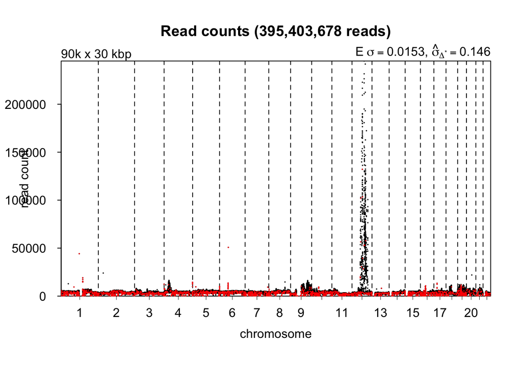

The default plotting style is OK, but squished and difficult to read. It mainly hightlights high levels of amplification on chr12 and 4. What else can you make out? Let’s try to make something nicer using ggplot.

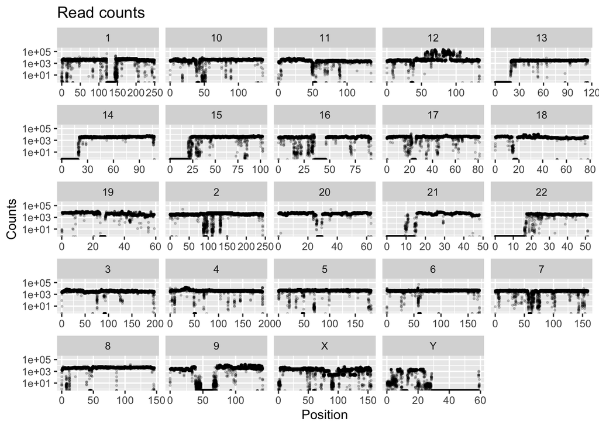

```r
dat = data.frame(
  chrom = readCounts@featureData@data$chromosome,
  Position = readCounts@featureData@data$start/1e6,
  Counts = readCounts@assayData$counts[, 1]
)
ggplot(dat, aes(x=Position, y=Counts)) +
  geom_point(size=0.5, alpha = 0.2) +
  facet_wrap(~chrom, scales="free_x") +
  scale_y_log10() +
  ggtitle("Read counts")
```

Noice, but the chromosomes are out of order (doh). You can fix this by making chrom an ordered factor.

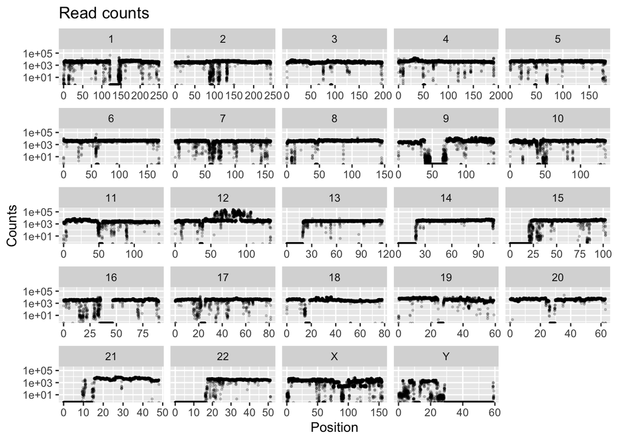

```r
chroms = c("1","2","3","4","5","6","7","8","9","10","11","12","13","14","15","16","17","18","19","20","21","22","X","Y")
dat$chrom = factor(dat$chrom, levels=chroms, ordered=TRUE)

ggplot(dat, aes(x=Position, y=Counts)) +
  geom_point(size=0.5, alpha = 0.2) +
  facet_wrap(~chrom, scales="free_x") +
  scale_y_log10() +
  ggtitle("Read counts")
```

Coolio. What do you think is going on with he genome?

QDNA-seq allows us to mask outliers and regions in dodgy parts of the genome. These are called blacklisted regions. We can also smooth and segment the data.

```r
readCountsFiltered <-
  applyFilters(readCounts, residual = TRUE, blacklist = TRUE)
```

```
## 103,199  total bins
##  96,043  of which in selected chromosomes
##  89,705  of which with reference sequence
##  83,607  final bins
```

```r
readCountsFiltered <- estimateCorrection(readCountsFiltered)
```

```
## Calculating correction for GC content and mappability
```

```
##     Calculating fit for sample ST059_NoIndex_bt2 (1 of 1) ...
```

```
## Done.
```

```
## Plotting sample copyNumbers (395,403,678 reads) (1 of 1) ...
```

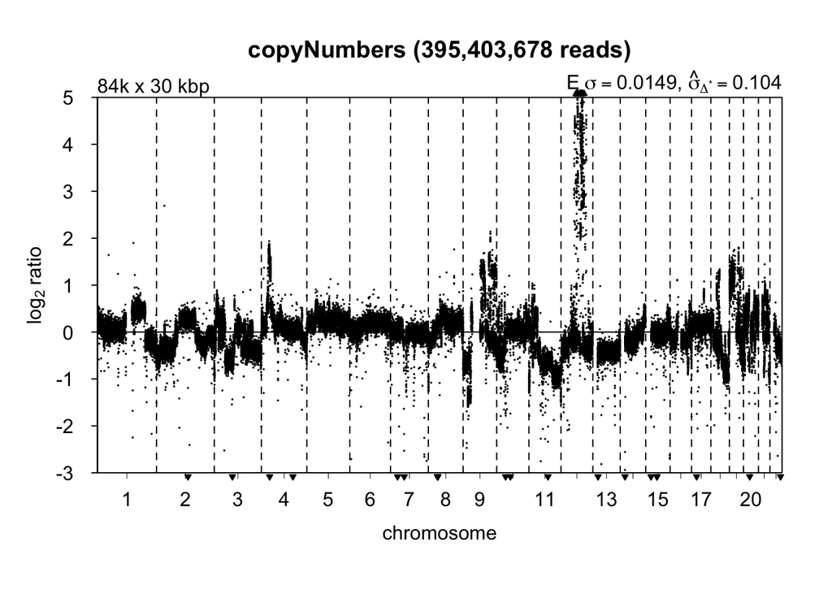

```r
copyNumbers <- correctBins(readCountsFiltered)
plot(copyNumbers, main="copyNumbers")
```

```r
copyNumbersNormalized <- normalizeBins(copyNumbers)
```

```
## Applying median normalization ...
```

```
## Plotting sample copyNumbersNormalized (395,403,678 reads) (1 of 1) ...
```

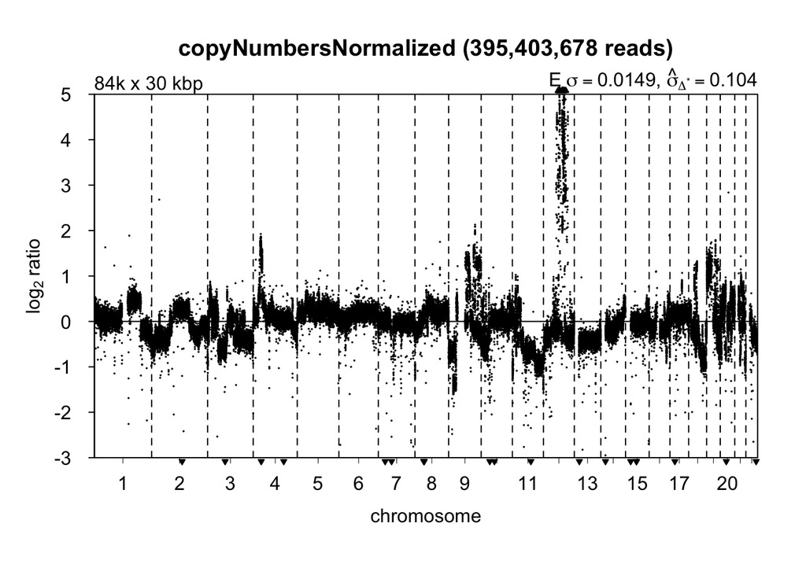

```r
plot(copyNumbersNormalized, main="copyNumbersNormalized")
```

```r
copyNumbersSmooth <- smoothOutlierBins(copyNumbersNormalized)
```

```
## Smoothing outliers ...
```

```
## Plotting sample copyNumbersSmooth (395,403,678 reads) (1 of 1) ...
```

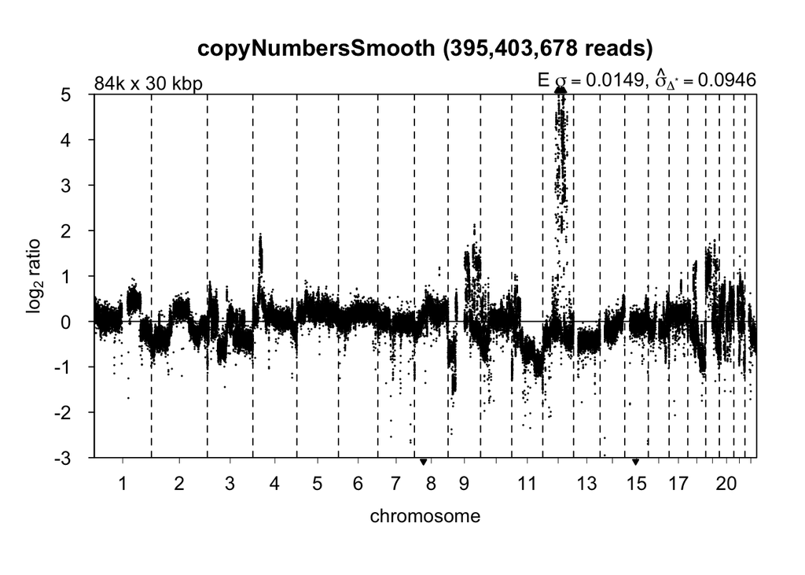

```r
plot(copyNumbersSmooth, main="copyNumbersSmooth")
```

We’ll export these results to look at in IGV if time permits.

```r
exportBins(copyNumbers, file = "ST059", format = "bed", type="copynumber")
exportBins(copyNumbers, file = "ST059.igv", format = "igv", type="copynumber")
exportBins(copyNumbers, file = "ST059.txt", type="copynumber")
```

We can also segment the data and call copy gain and loss.

```r
copyNumbersSegmented <-
  segmentBins(copyNumbersSmooth, transformFun = "sqrt")
```

```
## Performing segmentation:
```

```
##     Segmenting: ST059_NoIndex_bt2 (1 of 1) ...
```

```
## Plotting sample copyNumbersSegmented (395,403,678 reads) (1 of 1) ...
```

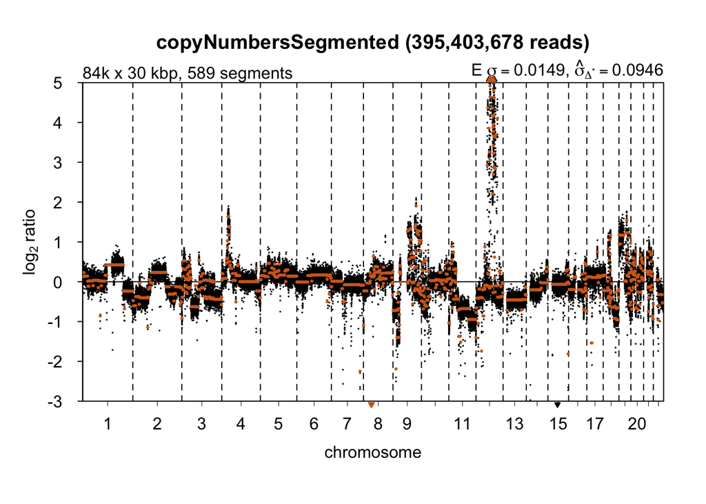

```r
copyNumbersSegmented <-
  normalizeSegmentedBins(copyNumbersSegmented)
plot(copyNumbersSegmented, main="copyNumbersSegmented")
```

```r
copyNumbersCalled <- callBins(copyNumbersSegmented)
```

```
## EM algorithm started ...
```

```
## [1] "Total number of segments present in the data: 589"
## [1] "Number of segments used for fitting the model: 100"
```

[output not shown]

[output cut: 244 more lines]

[output not shown]

[output not shown]

```
## Calling iteration1:
```

[output not shown]

[output cut: 544 more lines]

[output not shown]

```
## optim results
```

```
## time: 2
```

```
## minimum: 10730.9002509523
```

[output not shown]

[output not shown]

```
## Calling iteration2:
```

[output not shown]

[output cut: 544 more lines]

[output not shown]

```
## optim results
```

```
## time: 1
```

```
## minimum: 10732.9054281467
```

[output not shown]

```
## EM algorithm done ...
```

```
## Computing posterior probabilities for all segments ...
```

[output not shown]

[output cut: 1711 more lines]

[output not shown]

```
## Total time:0minutes
```

```
## Adjusting segmented data for cellularity ...
```

```
## Cellularity sample1: 1
```

```
## Adjusting normalized data for cellularity ...
```

```
## Cellularity sample1: 1
```

```
## 1
```

[output not shown]

[output not shown]

[output not shown]

[output not shown]

[output not shown]

[output not shown]

[output not shown]

[output not shown]

[output not shown]

[output not shown]

[output not shown]

[output not shown]

```
## FINISHED!
```

```
## Total time:0minutes
```

```
## Plotting sample copyNumbersCalled (395,403,678 reads) (1 of 1) ...
```

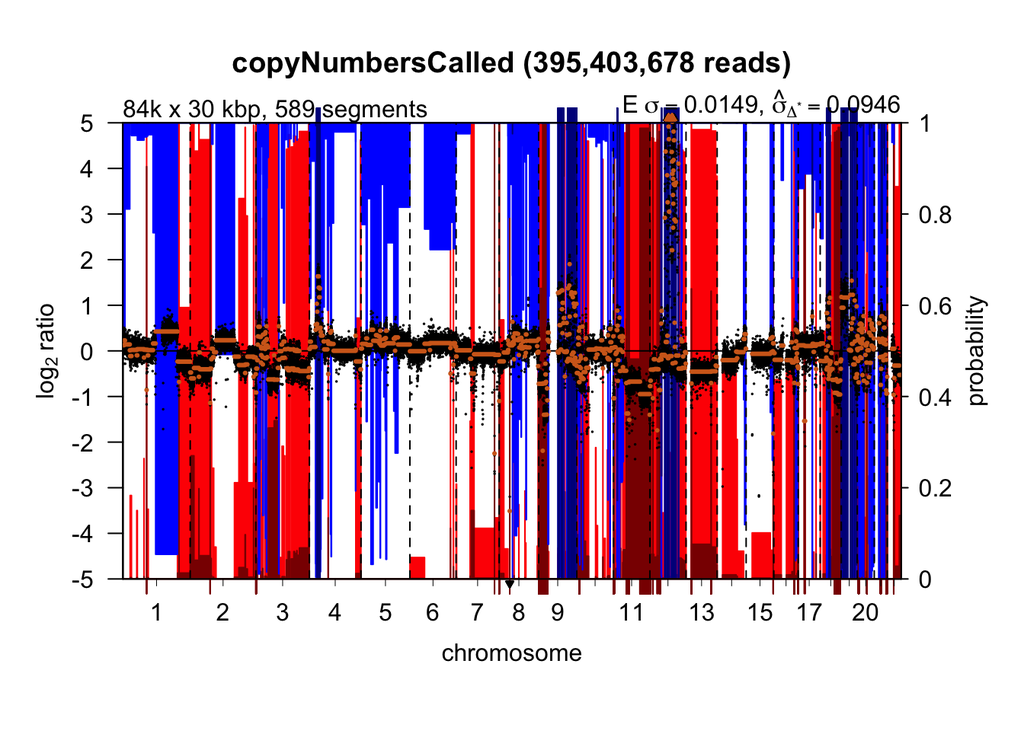

```r
plot(copyNumbersCalled, main="copyNumbersCalled")
```

```r
cgh <- makeCgh(copyNumbersCalled)
```

Now let’s take a closer look at chr12.

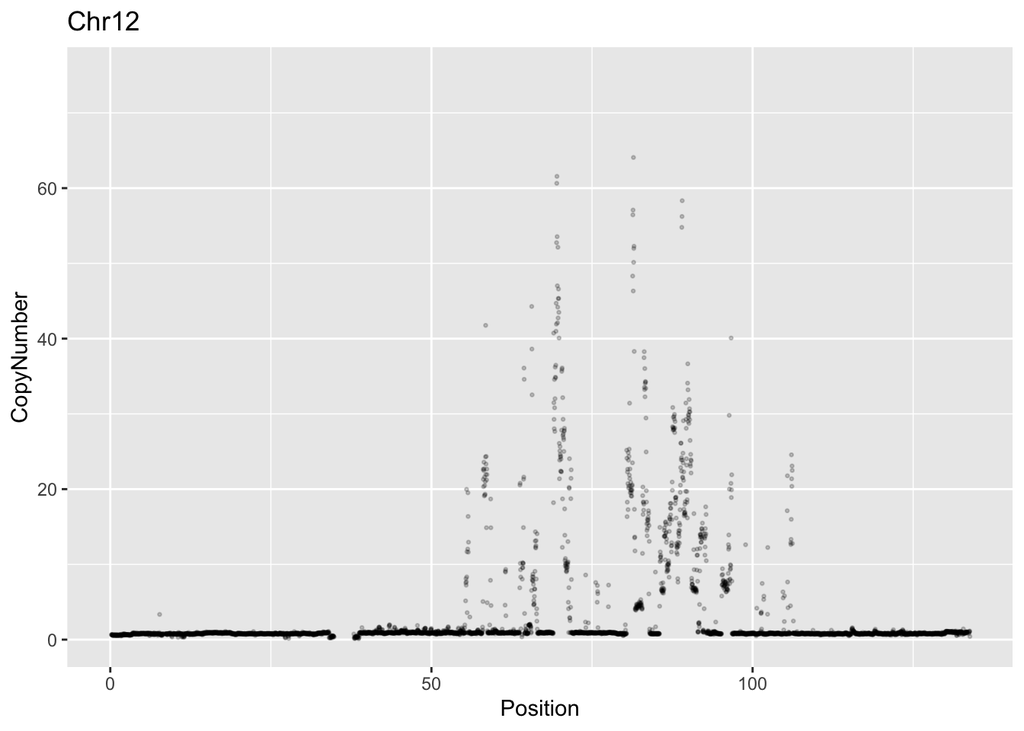

```r
dat = data.frame(
  chrom = copyNumbers@featureData@data$chromosome,
  Position = copyNumbers@featureData@data$start/1e6,
  CopyNumber = copyNumbers@assayData$copynumber[, 1]
)

dat1 = subset(dat, chrom=="12")
ggplot(dat1, aes(x=Position, y=CopyNumber)) +
  geom_point(size=0.5, alpha = 0.2) +
  scale_y_log10() +
  ylim(0.1, 75) +
  ggtitle("Chr12")
```

…and zooming in to some genes of interest

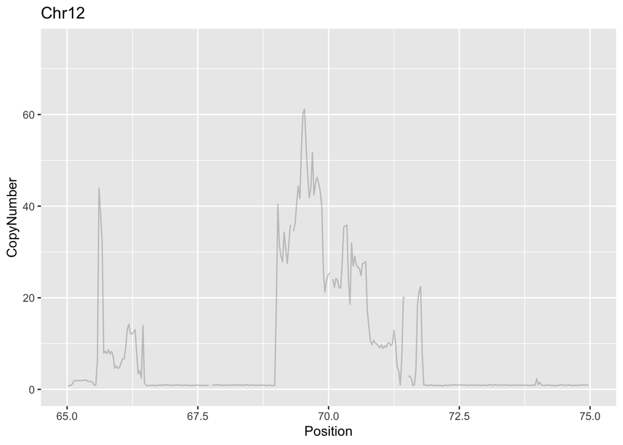

```r
dat = data.frame(
  chrom = copyNumbersSmooth@featureData@data$chromosome,
  Position = copyNumbersSmooth@featureData@data$start/1e6,
  CopyNumber = copyNumbersSmooth@assayData$copynumber[, 1]
)
dat2 = subset(dat, chrom=="12")
ggplot(dat2, aes(x=Position, y=CopyNumber)) +
  geom_line(size=0.5, alpha = 0.2) +
  scale_y_log10() +
  xlim(65, 75) +
  ylim(0.1, 75) +
  ggtitle("Chr12")
```

The oncogenes MDM2, CDK4 and HMGA2 are located on chr12 and frequently amplified in well-differentiated liposarcomas. The easiest way to check if any of these oncogenes are amplified in this tumour is to use IGV. If time permits, load the file ST059.igv into IGV and have a look at these genes.